[figure not shown]

# Factors of Ford GO Bike Trip Frequency & Trip Duration

### by Keerthana Manoharan

## Investigation Overview

In this investigation, I wanted to look out how the features of **trips** and **users** could influence the **trip frequency & trip duration**. The main focus was on the features of user (age, gender, user type) and trip (trip start day & hour).

## Dataset Overview

The dataset includes information about individual rides made in a bike-sharing system covering the greater San Francisco Bay area of the ford gobike for the year 2018. It has **18,63,721** ford gobike trip entries and **16** features.

## Trip Frequency Vs Trip Duration

Trip duration in the dataset takes on a very large range of values, from about **61 seconds (251 trips)** at the lowest, to about **86,366 seconds (1 trip)** at the highest. Plotted on a logarithmic scale, the distribution of trip duration takes on a unimodal shape which is mostly concentrated on the spectrum width of 250 - 1500 seconds.

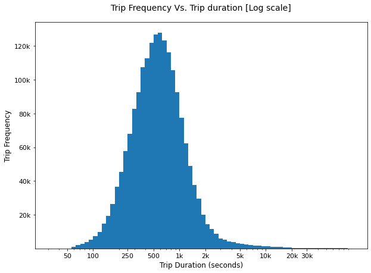

## Trip Frequency Vs. Day of the week

- **Weekdays** have more number of trips than **weekends**
- Especially, the trip count for mid three days of the week (Tue, Wed, Thurs) ranges between 320k and 314k

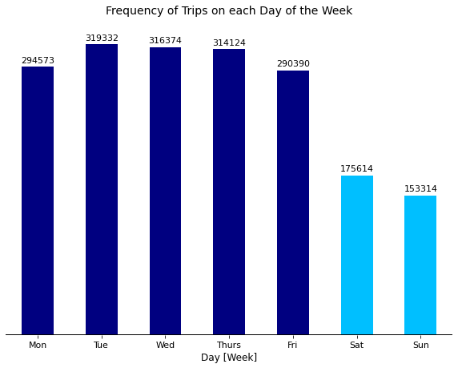

## Trip Frequency Vs. Hour of the Day

We can see that the peak hours are **8am - 9am** and **5pm - 6pm**

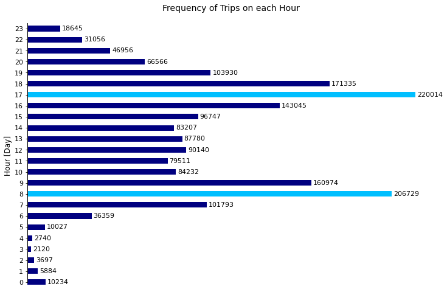

## Trip Frequency based on User Type & Gender

- We can see that the **Subscribers** uses the bike sharing system more frequently than **Customers**.
- Also, among them **Male** being the highest in frequency, followed by **Female, Users without personal information, Other**.

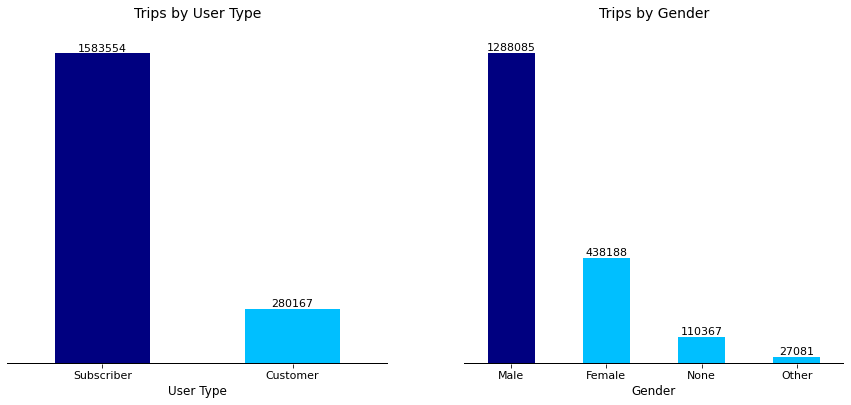

## Trip Frequency Vs. Trip Duration Vs. User Age

- It is seen that the high bike users are aged between **25 - 40**, having average trip duration around 500 seconds.
- The higher duration trips are performed almost uniformly by all age groups with low frequency.

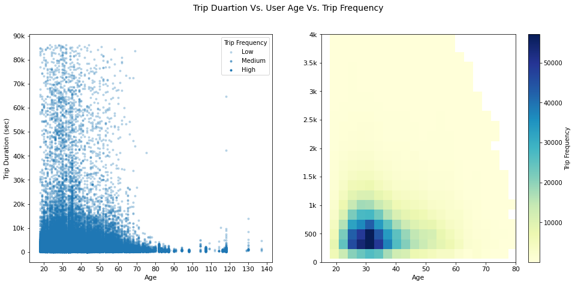

## How is the frequency of trips on each Hour of each Day of the Week for the users aged 25~50?

- In **Busy hours (8am & 5pm)**, frequency of **Subscriber** trips is higher than **Customer** trips during morning, while in the evening frequency of **Customer** trips is almost equal to **Subscriber** trips in **Week Days**.
- The frequency of trips in **Week ends** is higher for **Customer** rather than **Subscriber** during day time (10am-5pm)

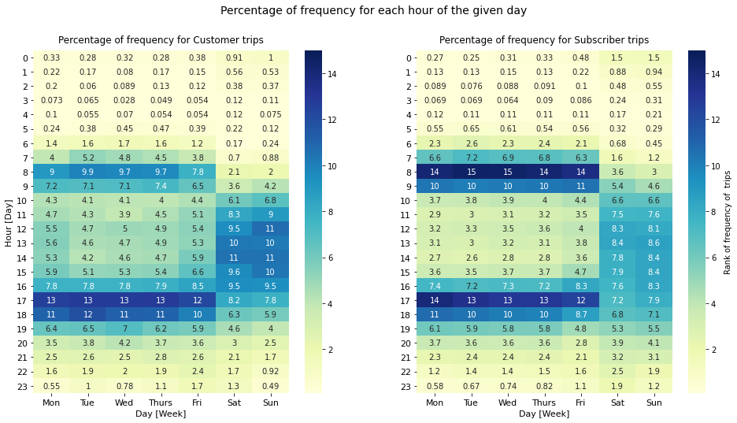

## Average Trip duration for Gender & User Type

- Eventhough, the **trip frequency** for Gender follows,

  > Male > Female > None(Users without personal data) > Other
- The overall order in **trip duration** is different as,

  > None(Users without personal data) > Female > Other > Male

While according to **User Type**, trip duration order changes as,

- **Subscriber: Females** have the higher trip duration, followed by **Other, Users without personal data, Male**
- **Customer: Users without personal data** have the high trip duration, followed by **Female, Other, Male**

**Note:** The null values is replaced by 'None' indicated that there was no information about the user. This may be due to they have used the service for one time long trip.

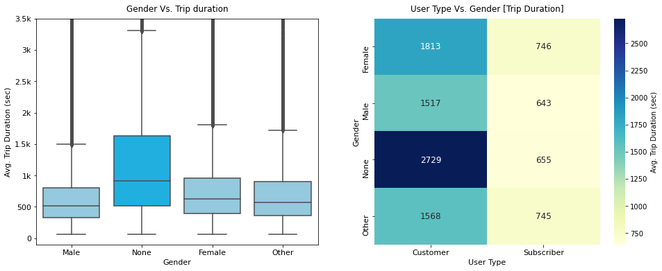

## Average Trip duration for Day[Week] & User Type

- Eventhough the number of trips are greater for **weekdays**, the duration in seconds is greater for **weekends**.
- It is also evident that **Customer** have the higher Trip duration than **Subscriber**, eventhough frequent trips is contributed by **Subscriber**.
- We can see that in both **Customer** and **Subscriber**, **weekends** have the higher trip duration, among which **Customer** has the highest.

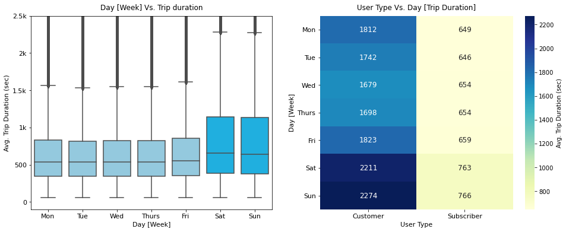

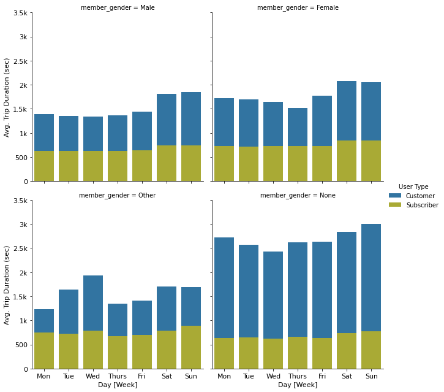

## Users of which age, contribute high trip duration ?

We have seen that the high bike users are aged between **25 - 40**, having average trip duration around 500 seconds. Then users of which age, contributed higher trip duration ?

- Early morning around **1am-4am**, user aged **60** goes for **high duration trips**.
- While, few elder users aged above **100** go for higher duration trips during **day time (5am-5pm)**.

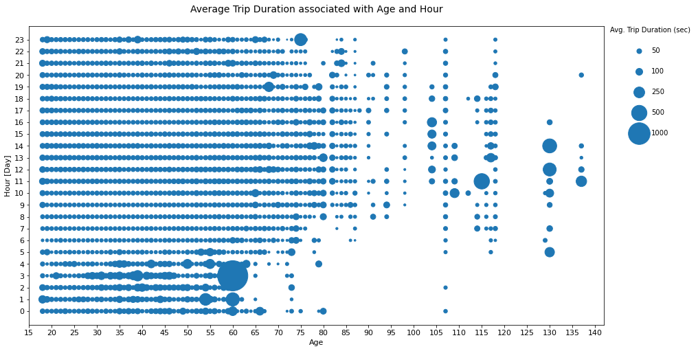

## Top 20 Busiest Route

The Busiest Route is from **San Francisco Ferry Building (Harry Bridges Plaza)** (ID:15) to **The Embarcadero at Sansome St** (ID:6) with trip count of **7585**

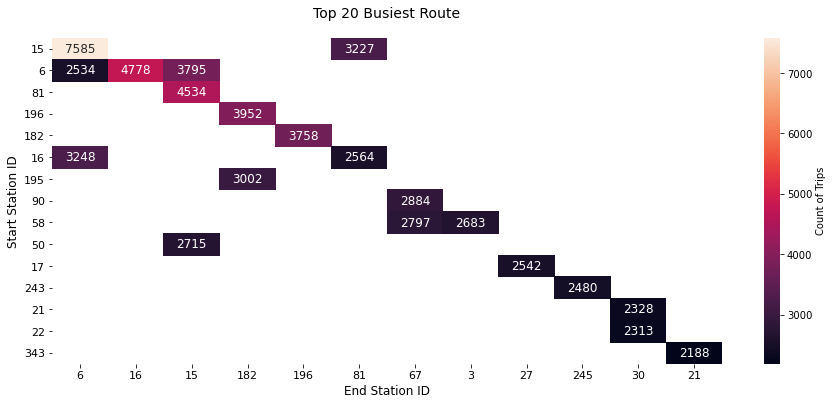